# Protecting Images from Hostile Classification Algorithms using Crypto-Secure Generated Noise

###### Background:

There has been significant discussion surrounding mandatory scanning of client data for illegal material (primarily CSAM). While eliminating CSAM is a laudable goal, what happens when client side scanning technology is inevitably co-opted by governments of a more authoritarian slant for different purposes? Regardless, the technology has now been created and hostile classifier models must now be considered when transmitting image data.

In papers such as the 'Learning to Break Deep Perceptual Hashing: The Use Case NeuralHash' (Struppek et al), it has been shown that this kind of classifier model are still sensitive to noise added to images by generative models. This raises an interesting question: is it possible to ensure that a classifier will 'always' misclassify an image (in a way that can be mathematically be proven) by adding noise to the image?

The interesting and novel part of the discussion notebook is that it attempts to directly peg the ability for a pattern recognition algorithm to recognise an image to the security of a cryptographic algorithm. This essentially means that any that any pattern recognition algorithm that functions correctly would have to create a 'mathematical break' in a cryptographic function (in this case, SHA-256). In deference to Microsoft's PhotoDNA, the algorithm presented below is referred to as the 'Bone Marrow Transplant'.

To demonstrate the concept in a practical way, the rest of this notebook considers an implementation of the Bone Marrow Transplant being used to protect data against the 'most feasible' scanning model presented by the European Union (outside of no encryption at all and key escrow) in 2020 was as follows:

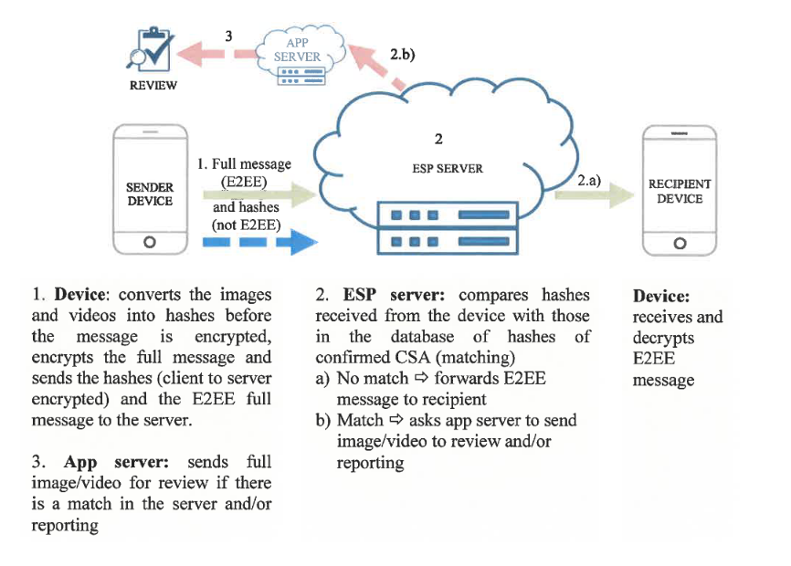

Given that the scanning model requires a plaintext image, it can be represented as an array of dimensions:

*Height x Width x 3 (one channel each for red, green and blue)*

Filled with integer values of the range 0-255. So we must maintain this format and scramble the channels.

Perhaps the simplest solution is to scramble each of the channels by adding a random number mod 256 (adding noise), and reversing the operation by subtracting the same mod 256 (removing the noise). The challenge in this case becomes two-fold:

*1. Ensuring that both the sender and receiver can generate the same random numbers*  
*2. Ensuring the randomness of the numbers*

To solve these issues I am using a ratchet with the SHA-256 hash function. In a 'practical useful' implementation (i.e. messaging app etc) the seed for the first iteration of the ratchet being would be shared in the encrypted channel as either an image caption or similar. Alternatively, if no encrypted channel was available this seed could be a shared secret between parties based on a key exchange protocol(eg ECDH, NEWHOPE etc). This would allow the scramble to operate securely in a completely unencrypted environment.

At each subsequent cycle of the ratchet the previous hash is appended to the input and the input is trimmed if required to stay within a pre-specified buffer size bounds (this is set based on security requirements). In a diagram:

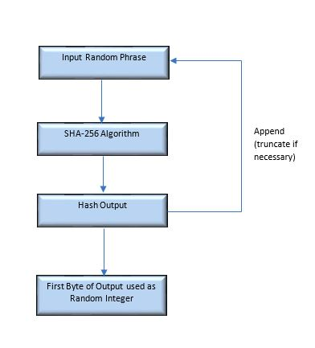

This is obviously very computationally expensive(for a 576x768 image 1327104 hashes must be generated). This takes ~6.9 seconds on an AMD Ryzen 5 2600x and would obviously take significantly longer on a smartphone. Further information on this(including justification for doing it like this) is found in the next section. Worst case security should be the same as finding a hash collision in SHA-256.

The unscrambling process is exactly the reverse of the scrambling process.

Examples of both the scrambling and unscrambling processes in Python code below:

###### Scramble

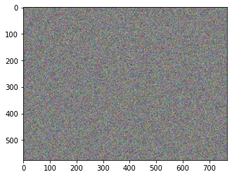

```python
import hashlib
from PIL import Image
import numpy as np
import matplotlib.pyplot as plt

tst_img = Image.open("dog.jpeg")
pix = np.array(tst_img)

### START SCRAMBLE (SENDER) ###

# Bob generates secret and uses it to scramble the images. He then shares the secret with
# Alice over an encrypted channel or using a key exchange if an encrypted channel is not available:
c_init = "Things and stuff for data scramble"
c = str(c_init).encode()
hash_cutoff_length = 1024

for i in range(0, pix.shape[0]):
    for k in range(0, pix.shape[1]):
        for j in range(0, 3):

            c_out = hashlib.sha256(c)
            r = int.from_bytes(c_out.digest()[0:1], 'big')
            pix[i, k, j] = (pix[i, k, j] + r) % 256
            c = c + c_out.digest()

            # Trim it if out input is getting too long
            if len(c) > hash_cutoff_length:
                start_val = len(c) - hash_cutoff_length
                c = c[start_val:hash_cutoff_length]

out_img = Image.fromarray(pix)
#out_img.show()
plt.imshow(out_img)
```

###### Unscramble

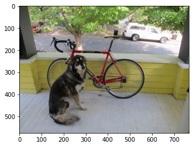

```python
### START RECOVERY (RECEIVER) ###

# Alice then recovers the original image:
c_init = "Things and stuff for data scramble"
c = str(c_init).encode()

for i in range(0, pix.shape[0]):
    for k in range(0, pix.shape[1]):
        for j in range(0, 3):

            c_out = hashlib.sha256(c)
            r = int.from_bytes(c_out.digest()[0:1], 'big')
            pix[i, k, j] = (pix[i, k, j] - r) % 256
            c = c + c_out.digest()

            # Trim it if out input is getting too long
            if len(c) > hash_cutoff_length:
                start_val = len(c) - hash_cutoff_length
                c = c[start_val:hash_cutoff_length]

out_img = Image.fromarray(pix)
#out_img.show()
plt.imshow(out_img)
```

###### Optimizations and Why I Have Done It In Such A Computationally Expensive Way (a kinda sorta proof):

At the core of any of these computer vision solutions for detecting similar images(deep learning or otherwise) is pattern recognition. This can essentially be described as recognising the relationship of individual pixels to each other in an image. Note that this is not necessarily the same as the values of the pixels themselves. See code below in next cell for example of all pixel values being shifted while preserving underlying relationships.

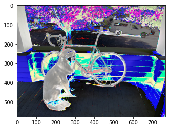

```python
# For this demonstration we are just going to go with the relationship being m=n(i.e. r in the code below) as
# this results in an easily understandable example for the human eye. Algorithms could also discover other relationships
# if trained properly (m = 2n etc).

# As you can see, even though even pixel has had it's channel values modified, the relationships still exist so it is still
# vunerable to pattern recognition.

###START BY RELOADING THE IMAGE###

tst_img = Image.open("dog.jpeg")
pix = np.array(tst_img)

#PICK A RANDOM INTEGER HERE
r = 129

for i in range(0, pix.shape[0]):
    for k in range(0, pix.shape[1]):
        for j in range(0, 3):
            pix[i, k, j] = (pix[i, k, j] + r) % 256

out_img = Image.fromarray(pix)
#out_img.show()
plt.imshow(out_img)
```

So what we need to do is obscure this relationship by truly randomising each channels value. If we can prove that the relationship between any two pixels has become completely random, we can prove the security of the Bone Marrow Transplant against any pattern recognition algorithm that relies on these relationships. As an attempt at a formal mathematical definition; A pattern recognition identifies an image based on the set $R$, which is composed as follows:

Let $r\in R$ be a relationship between some pixel $a\in P$ and some other pixel $b\in P$, where $P$ is the set of all pixels in the image.

So, based on that definition we attempt to prove the properties of the Bone Marrow Transplant by contradiction:

Let $pic$ be an image with a height of $H$ and a width of $W$. Let $i$, $j$, $k$, $l$ be integer index values such that $i$, $k$ < $H$ and $j$, $l$ < $W$. Let there be a relationship $r$ between pixels $pic[i][j]$ and $pic[k][l]$ such that it is detectable by a pattern recognition algorithm after being processed by the scramble.

$pic[i][j]$ = plaintext($pic[i][j]$) + $m$ where $m$ is a random integer between 0-255  
$pic[k][l]$ = plaintext($pic[k][l]$) + $n$ where $n$ is a random integer between 0-255

For $r$ between plaintext($pic[i][j]$) and plaintext($pic[k][l]$) to be discoverable by the algorithm, there must be a relationship between $m$ and $n$ that is also discoverable by the algorithm. But for there to be a relationship between $m$ and $n$, there would have to be a discoverable relationship between the outputs for two different inputs of the SHA-256 algorithm. This is a contradiction of the cryptographic properties of SHA-256.

Therefore: As long as the cryptographic properties of SHA-256 hold, no current pattern recognition algorithm can detect images which have been transformed using the Bone Marrow Transplant.

As you can see, the reason I have done it in such a computationally expensive way is so that this proof can hold. In reality, there will be plenty of 'good enough' solutions that will do things like using the same generated randoms for a few pixels (say a 3x3 square for example) and be undetectable based on probabilites, but the proofs for these will be different and need further research.

Thankyou for reading this notebook :)